# Measuring the Participation in the ACCELERATE Natural History Registry

```r
#median age at diagnosis is 39 years old.
```

Below you can see that we have more female participants in our registry than male participants.

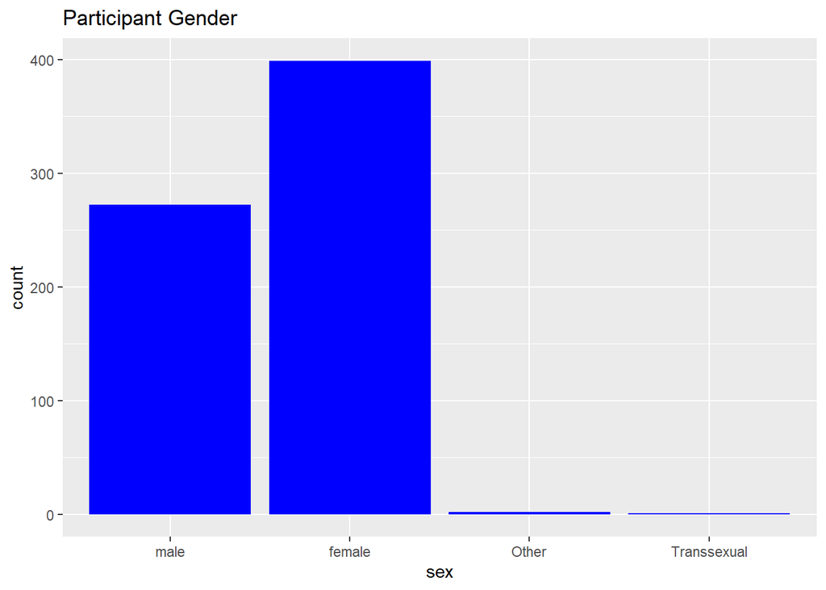

```r
#chart gender of participants
ggplot(data=demographic, aes(x=sex))+
  geom_bar(fill='blue')+
  ggtitle("Participant Gender")
```

Below you can see that most of our registry participants identify as white.

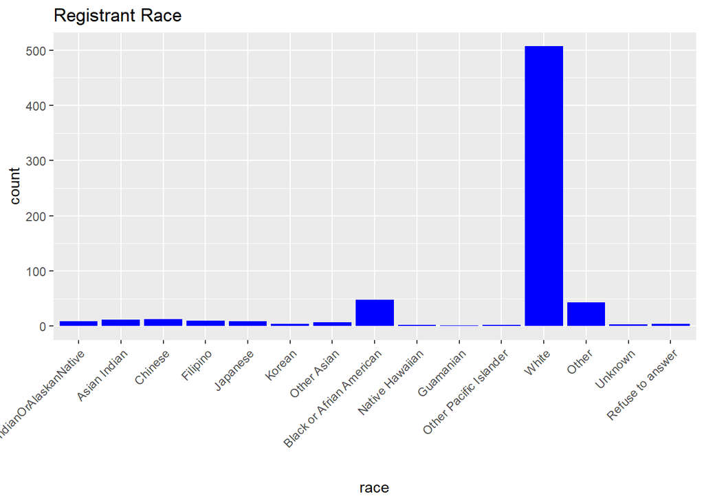

```r
ggplot(data=demographic, aes(x=race))+
  geom_bar(fill='blue')+
  theme(axis.text.x = element_text(angle=45, hjust=1))+
  ggtitle("Registrant Race")
```

When reviewing diagnosis information, we can see that most of our participants self identify as having HHV8-unknown multicentric Castleman disease (MCD) or unicentric Castleman disease (UCD).

```r
#Here I am going to breakdown diagnosis by sex.

#changing the column name to something more useful.
colnames(demographic.with.diagnosis)[22]="CD_Diagnosis"

class(demographic.with.diagnosis$CD_Diagnosis)
```

```
[1] "integer"
```

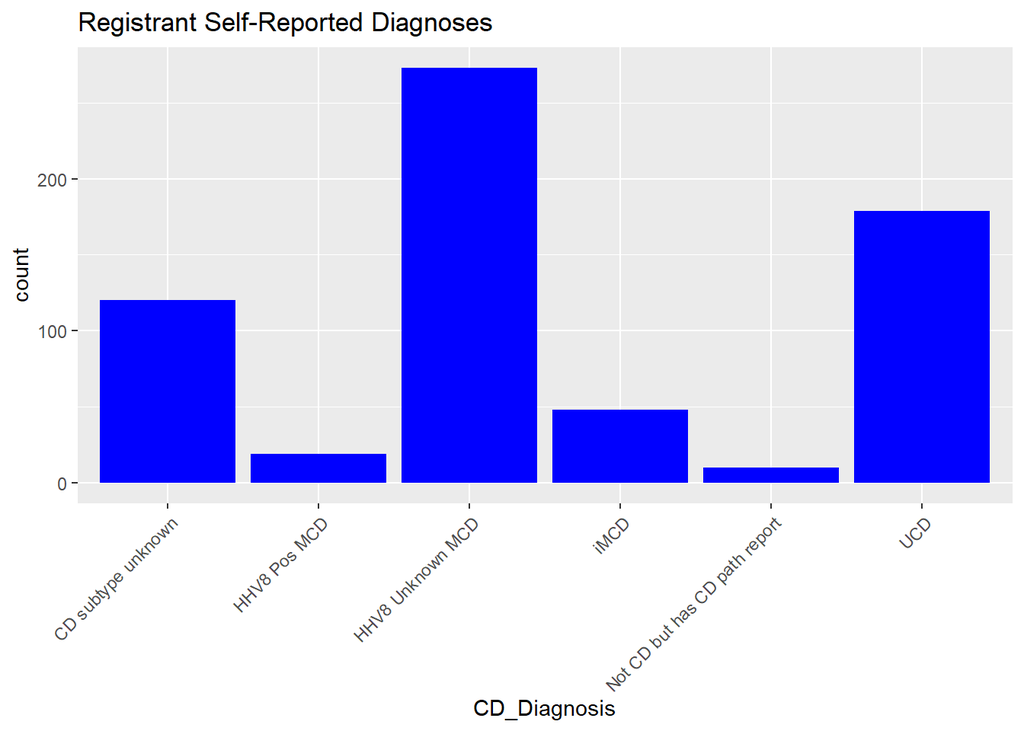

```r
#Labelling the diagnoses
demographic.with.diagnosis<- mutate(demographic.with.diagnosis, CD_Diagnosis
                                    =case_match(CD_Diagnosis,
                                                1~"CD subtype unknown",
                                                2~"UCD",
                                                3~"HHV8 Pos MCD",
                                                4~"HHV8 Unknown MCD",
                                                5~"iMCD",
                                                6~"Not CD but has CD path report"
                                                                                        ))

#First, just a plot of diagnosis count.
ggplot(data=demographic.with.diagnosis, aes(x=CD_Diagnosis))+
  geom_bar(fill='blue')+
  theme(axis.text.x = element_text(angle=45, hjust=1))+
  ggtitle("Registrant Self-Reported Diagnoses")
```

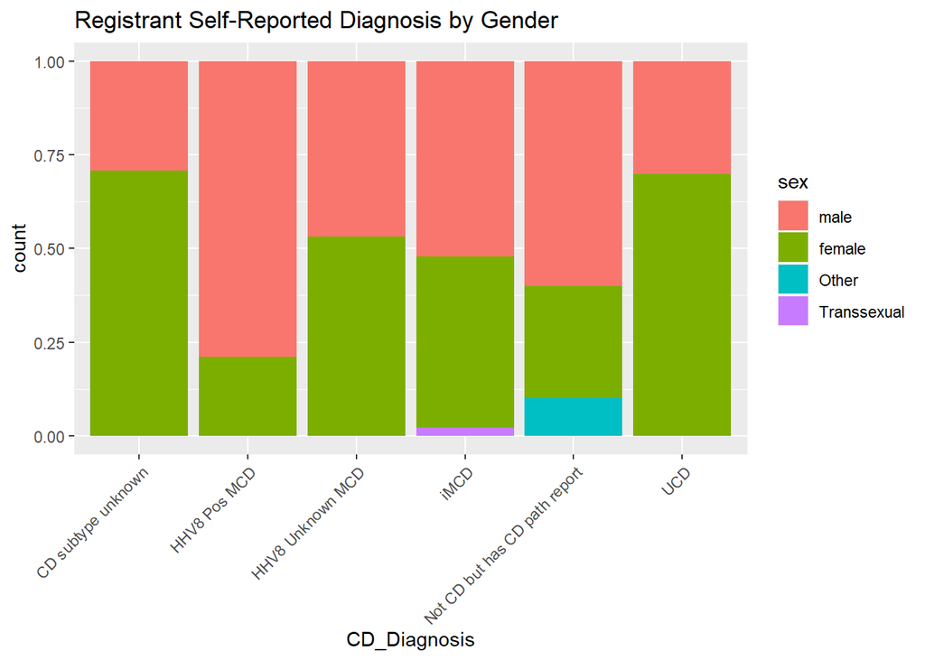

```r
#Plot of diagnosis by gender.
ggplot(data=demographic.with.diagnosis, aes(x = CD_Diagnosis, fill = sex)) +
    geom_bar(position = "fill")+
  theme(axis.text.x = element_text(angle=45, hjust=1))+
  ggtitle("Registrant Self-Reported Diagnosis by Gender")
```

## 4 Results

In the results, I will begin to review the interactions and impacts between the registry and our population. I will review 4 main ideas. First, the average length of time from symptom onset to time of diagnosis to indicate how fast our population is receiving a diagnosis. You can see below that the average time from symptom onset to diagnosis is 147 days. This can be concerning for our patient population as some experience severe symptoms that potentially lead to death. We would hope patients would be diagnosed at a faster rate.

```r
#Average length of time from symptom onset to time of diagnosis. This tells us whether our recently published diagnostic criteria have affected the the rate in which patients are diagnosed.

#adding a new column called years from symptom onset to diagnosis.
demographic.with.diagnosis<-
  mutate(demographic.with.diagnosis, Years_from_symptom_onset_to_diagnosis=as.numeric(demographic.with.diagnosis$date_at_diagnosis-demographic.with.diagnosis$date_symptoms_began)/365)

demographic.with.diagnosis|>
  summarize(Years_from_symptom_onset_to_diagnosis=median(Years_from_symptom_onset_to_diagnosis, na.rm=TRUE))
```

```
  Years_from_symptom_onset_to_diagnosis
1                             0.4027397
```

```r
#Average time from symptom onset to diagnosis is 0.4 years.

#Will do the same in days.
demographic.with.diagnosis<-
  mutate(demographic.with.diagnosis, Time_from_symptom_onset_to_diagnosis=as.numeric(demographic.with.diagnosis$date_at_diagnosis-demographic.with.diagnosis$date_symptoms_began))

demographic.with.diagnosis|>
  summarize(Time_from_symptom_onset_to_diagnosis=median(Time_from_symptom_onset_to_diagnosis, na.rm=TRUE))
```

```
  Time_from_symptom_onset_to_diagnosis
1                                  147
```

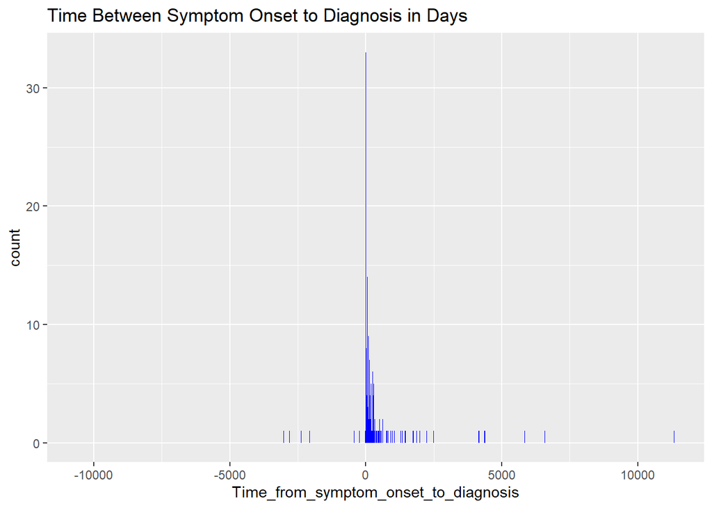

```r
#Average time from symptom onset to diagnosis is 147 days.

ggplot(demographic.with.diagnosis, aes(x = Time_from_symptom_onset_to_diagnosis)) +
    geom_histogram(fill='blue',binwidth = 4)+
  ggtitle("Time Between Symptom Onset to Diagnosis in Days")
```

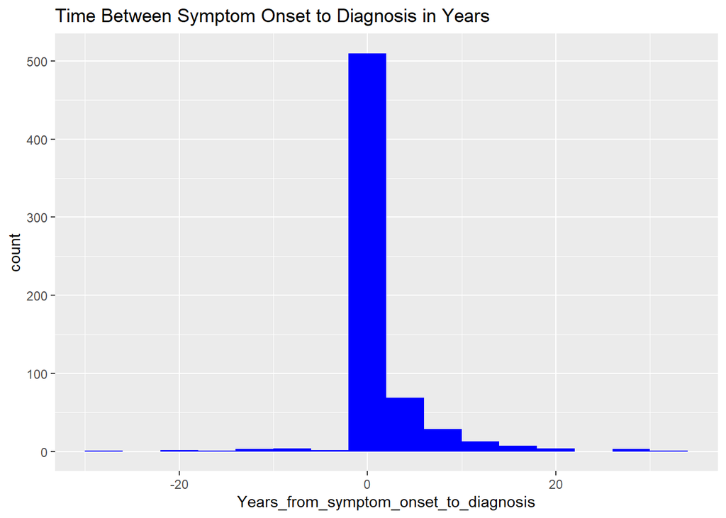

```r
ggplot(demographic.with.diagnosis, aes(x = Years_from_symptom_onset_to_diagnosis)) +geom_histogram(fill='blue',binwidth = 4)+
  ggtitle("Time Between Symptom Onset to Diagnosis in Years")
```

```r
#Now lets look at how the date of diagnosis differs on forms to see if patients are filling out forms correctly.to check for patient understanding/gaps in patient engagement.

#joining the two forms: diagnostic and eligibility.
eligibility.with.diagnosis <- inner_join(eligibility, diagnosis, by="patient_id")


#converting both objects to a date format
eligibility.with.diagnosis$date_at_diagnosis<-as.Date(eligibility.with.diagnosis$date_at_diagnosis, format="%m/%d/%Y")

eligibility.with.diagnosis$date_on_diagnostic_pathology_report<-as.Date(eligibility.with.diagnosis$date_on_diagnostic_pathology_report, format="%m/%d/%Y")

#adding new column= diagnosis.date.diff (difference between the two dates on the two forms)
eligibility.with.diagnosis<-
  mutate(eligibility.with.diagnosis, diagnosis.date.diff=as.numeric(eligibility.with.diagnosis$date_on_diagnostic_pathology_report-eligibility.with.diagnosis$date_at_diagnosis))

#Median difference between the two dates is 0, indicating that most patients are accurately/consistently recording their date of a diagnostic path report in one form as the date of diagnosis in another.
eligibility.with.diagnosis|>
  summarize(diagnosis.date.diff=median(diagnosis.date.diff, na.rm=TRUE))
```

```
  diagnosis.date.diff
1                   0
```

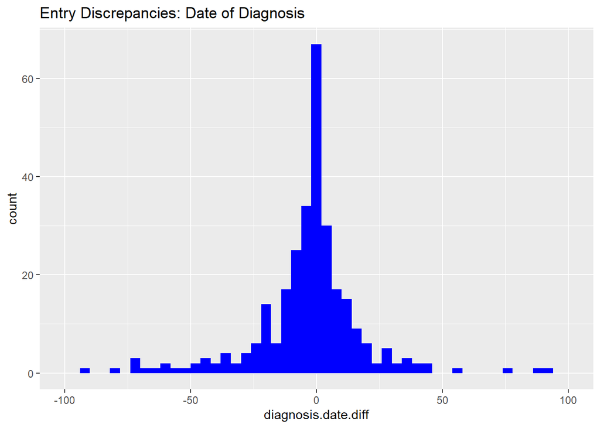

```r
#Plot
ggplot(eligibility.with.diagnosis, aes(x = diagnosis.date.diff)) +
    geom_histogram(fill='blue', binwidth = 4)+
  xlim(-100, 100)+
  ggtitle("Entry Discrepancies: Date of Diagnosis")
```

Third, I am analyzing the date of diagnosis to date of enrollment in our registry. This will shed some light on our recruitment strategies. Median date of consent is 346 days after date of diagnosis. This means, it takes patients about 1 year to become involved in our research. This is a gap we would like to shorten.

```r
#Date of diagnosis to date of enrollment in registry.

#converting consent date to a date format.
eligibility.with.diagnosis$consent_date<-as.Date(eligibility.with.diagnosis$consent_date, format="%m/%d/%Y")

#adding new column= consent.date.diff (difference between the two dates on the two forms)
eligibility.with.diagnosis<-
  mutate(eligibility.with.diagnosis, consent.date.diff=as.numeric(eligibility.with.diagnosis$consent_date-eligibility.with.diagnosis$date_at_diagnosis))


#Median difference between the two dates. Median date of consent is 346 days after date of diagnosis.
eligibility.with.diagnosis|>
  summarize(consent.date.diff=median(consent.date.diff, na.rm=TRUE))
```

```
  consent.date.diff
1               346
```

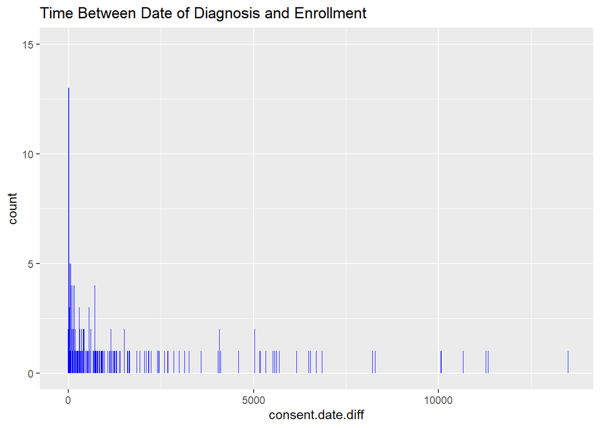

```r
#plot
ggplot(eligibility.with.diagnosis, aes(x = consent.date.diff)) +
    geom_histogram(fill='blue', binwidth = 4)+
  ylim(0,15)+
  ggtitle("Time Between Date of Diagnosis and Enrollment")
```

```r
sum(eligibility.with.diagnosis$consent.date.diff<0)
```

```
[1] 3
```

```r
#This count tells us that 3 patients consented to the registry before even having a diagnosis and that 8 patients consented the same day. This seems unlikely and most likely means that patients are automatically writing their date of diagnosis as "today's date" when they are completing the forms. However, this is only a small portion of patients.
```

[output not shown]

```r
library(tidyverse)
library(sf)
library(RColorBrewer)
library(tigris)
library(grid)
library(leaflet)
library(tigris)
library(tmap)
library(RColorBrewer)
```

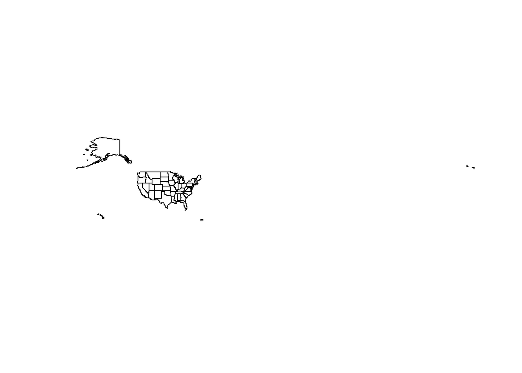

```r
#Downloading state data.
st<-states(cb=T, resolution="20m")
plot(st$geometry)
```

```r
us.states<-st|>
  filter(!STATEFP %in% c("02", "11",
                            "15", "60",
                            "66", "69",
                            "72", "78"))

colnames(demographic.with.diagnosis)[10]="STUSPS"


#Created a dataframe with patient counts for each state.
df1<-demographic.with.diagnosis|>
  group_by(STUSPS)|>
  summarise(patient_id=n())

#joining with demographic data from registry with the geographic data.

map2<- left_join(us.states, df1, by="STUSPS")
```

```r
#making interactive leaflet map.

pal_fun <- colorBin(palette = brewer.pal(9, "Blues"),
                    bins = c(1, 5, 10, 20, 30, 40, 50))

#add pop up message
pu_message <- paste0(map2$STUSPS,
                     "<br># patients: ",
                     map2$patient_id)

leaflet(map2) |>
  addPolygons(stroke = FALSE,
              fillColor = ~ pal_fun(patient_id),
              fillOpacity = 0.7, smoothFactor = 0.5, #
              popup = pu_message) |>
  addProviderTiles(providers$Stadia.StamenTonerLite) |>
  addLegend("bottomright",
            pal = pal_fun,
            values = ~ patient_id,
            title = 'Patients Participating in ACCELERATE',
            opacity = 1) |>
  addScaleBar()
```

[interactive chart not shown]

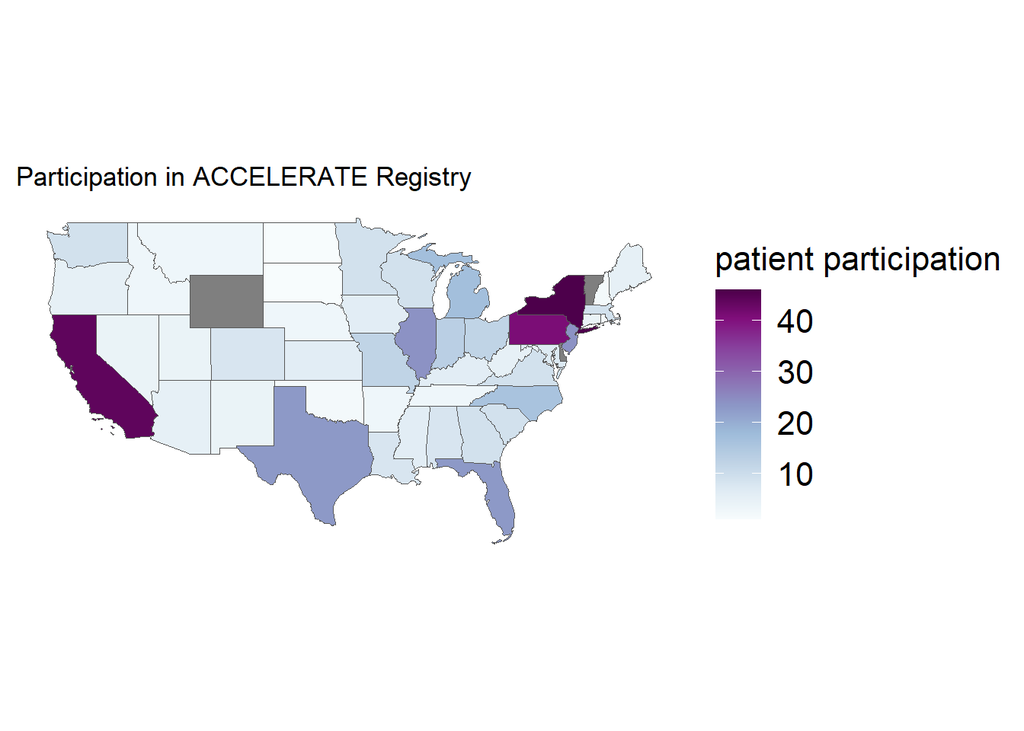

```r
#Static map with the same data..

myPalette <- colorRampPalette(brewer.pal(9, "BuPu"))

my_theme <- function() {
  theme_minimal() +
  theme(axis.line = element_blank(),  # further customization of theme components
        axis.text = element_blank(),  # remove x and y axis text and labels
        axis.title = element_blank(),
        panel.grid = element_line(color = "white"),  # make grid lines invisible
        legend.key.size = unit(0.8, "cm"),           # increase size of legend
        legend.text = element_text(size = 16),       # increase legend text size
        legend.title = element_text(size = 16))
}

ggplot() +
  geom_sf(data = us.states, aes(fill = map2$patient_id)) +
  ggtitle("Participation in ACCELERATE Registry") +
  my_theme()+
  scale_fill_gradientn(name = "patient participation",
                    colours = myPalette(100))
```

## 5 Conclusion

Lastly, the patient participation interactive map is a great addition to our team’s resources as we can continuously track patient participation throughout the US and clearly identify regions that need more contact, support, and recruitment into our research studies.

## 6 References

Zhang X, Rao H, Xu X, et al. Clinical characteristics and outcomes of Castleman disease: A multicenter study of 185 Chinese patients. *Cancer Sci*. 2018;109(1):199-206. doi:10.1111/cas.13439